# act_report

## WeRateDogs: Act Report

From my wrangling and cleaning efforts I was able to gain meaningful insights in the complete dataset that was put together from three separated data sources. This enabled me to also produce visualizations to communicate my findings pictorially and more clearly.

### Insights:

1. There are a lot of high ratings in this dataset From the analysis I discovered that there was a high number of highly rated tweets. The plot below shows the number of tweets with their ratings.

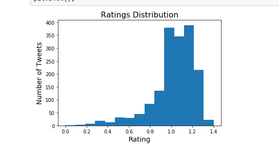

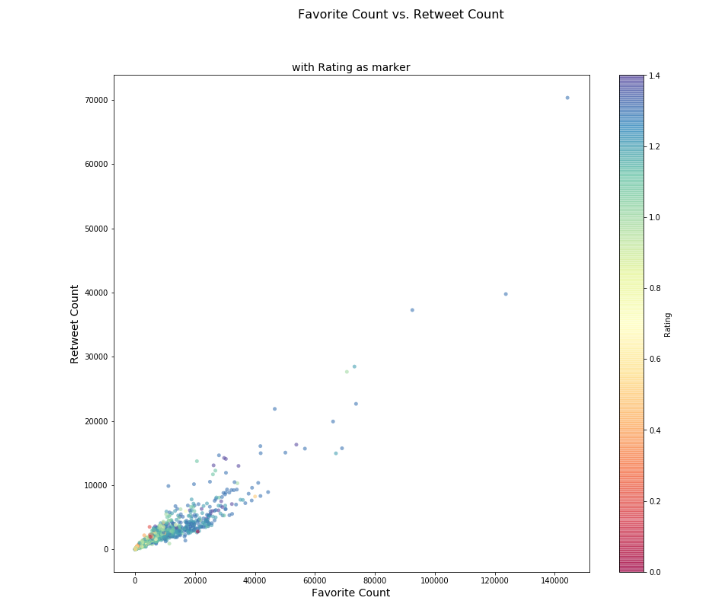

1. The highest predicted dog is the golden retriever. From the data analysis preformed I discovered that the dog that was predicted the most was the golden retriever. The plot below shows that clearly.

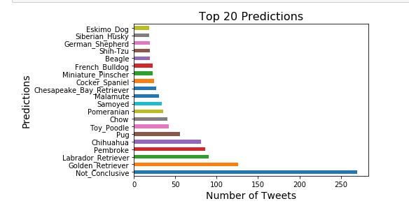